# CAISO data

This workbook analyses CAISO demand data along with generation from renewables (wind and solar only) in an attempt to determine how much storage (and at what duration) may be needed in the California markets as grid penetration of renewable generation assets (again, speicfically wind and solar) increases.

### Key Questions to be addressed:

- High-level assessment of the current state of energy in CA (energy produced in a 1-year period, peak demand, and the current fraction of overall delivered energy that has come from wind and solar)
- How much energy needs to be shifted and by how long and for what level of renewable penetration?
- What is the optimal mix of wind and solar on the grid and how does that optimum vary based on extent of renewable penetration?

### Data Cleaning

Data for a 1-year period (from July 1, 2018 to June 30, 2019), have been sourced from CAISO. These data contain information on total demand in the CAISO region, along with production from wind and solar plants.

```python
# load packages

import numpy as np
import matplotlib.pyplot as plt
import pandas as pd
import os
from datetime import datetime, timedelta
from functools import reduce
import pytz
import matplotlib.dates as mdates
import time

import datetime as dt

%matplotlib inline
```

```python
# Load data

# Directories
dirs = ['Demand', 'Renewables']

# labels
months = ['2018 - July',
          '2018 - August',
          '2018 - September',
          '2018 - October',
          '2018 - November',
          '2018 - December',
          '2019 - January',
          '2019 - February',
          '2019 - March',
          '2019 - April',
          '2019 - May',
          '2019 - June']

demand     = pd.DataFrame()
renewables = pd.DataFrame()

for m in months:
    path_demand     = os.getcwd() + '/'  + dirs[0] + '/' + m + ' ' +  dirs[0] +  '.csv'
    path_renewables = os.getcwd() + '/'  + dirs[1] + '/' + m + ' ' +  dirs[1] +  '.csv'
    demand     = demand.append(pd.read_csv(path_demand),ignore_index=True)
    renewables = renewables.append(pd.read_csv(path_renewables),ignore_index=True)
    print(m.split(' ')[-1])
```

```
July
August
September
October
November
December
January
February
March
April
May
June
```

```python
CAISO = demand[(demand.MARKET_RUN_ID == 'RTM') &
               (demand.TAC_AREA_NAME == 'CA ISO-TAC') &
               (demand.EXECUTION_TYPE == 'RTD')][['INTERVALSTARTTIME_GMT','MW']]

CAISO.rename(columns = {'INTERVALSTARTTIME_GMT': 'Date Time',  'MW': 'Demand (MW)'}, inplace=True)
```

```python
# Create wind dataframe
Wind = renewables[(renewables.MARKET_RUN_ID == 'RTD') &
                  (renewables.RENEWABLE_TYPE == 'Wind')][['INTERVALSTARTTIME_GMT','MW']]

Wind.rename(columns = {'INTERVALSTARTTIME_GMT': 'Date Time',  'MW': 'Wind (MW)'}, inplace=True)

# Create solar dataframe
Solar = renewables[(renewables.MARKET_RUN_ID == 'RTD') &
                   (renewables.RENEWABLE_TYPE == 'Solar')][['INTERVALSTARTTIME_GMT','MW']]

Solar.rename(columns = {'INTERVALSTARTTIME_GMT': 'Date Time',  'MW': 'Solar (MW)'}, inplace=True)
```

```python
# Group by date to sum wind and solar across CAISO regions
Wind  = Wind.groupby('Date Time').sum()
Wind.reset_index(inplace=True)

Solar = Solar.groupby('Date Time').sum()
Solar.reset_index(inplace=True)
```

```python
# Create a function to convert 'Date Time' column from str datatype to datetime datatype
def new_time(df):
    # Parse time column
    df['Year']   = df['Date Time'].str[0:4]
    df['Month']  = df['Date Time'].str[5:7]
    df['Day']    = df['Date Time'].str[8:10]
    df['Hour']   = df['Date Time'].str[11:13]
    df['Minute'] = df['Date Time'].str[14:16]

    # Create list of columns that will be converted to datetime datatype
    time = ['Year','Month','Day','Hour','Minute']

    # Convert to datetime
    df['Time']   = pd.to_datetime(df[time].astype(str).apply(' '.join, 1), format='%Y %m %d %H %M')
    df['Time']   = df['Time'].dt.tz_localize('UTC').dt.tz_convert('US/Pacific')

    # Append original Date Time column to list of columns to be dropped
    time.append('Date Time')

    # Drop time columns that are no longer needed
    df.drop(time,axis=1,inplace=True)
    return(df)
```

```python
CAISO = new_time(CAISO)
Wind  = new_time(Wind)
Solar = new_time(Solar)
```

```python
# Create a new dataframe with all time intervals, as some are missing from CAISO, Wind, and Solar dataframes
start_time = datetime(2018,7,1,7,0)
end_time   = datetime(2019,7,1,7,0)

t = np.arange(start_time, end_time, timedelta(minutes=5)).astype(datetime)
df_t = pd.DataFrame(t,columns=['Time'])
df_t.Time = df_t.Time.dt.tz_localize('UTC').dt.tz_convert('US/Pacific')

# Print out lengths
print('Datapoints in CAISO dataframe: {}'.format(CAISO.shape[0]))
print('Datapoints in Wind dataframe:  {}'.format(Wind.shape[0]))
print('Datapoints in Solar dataframe: {}'.format(Solar.shape[0]))
print('Datapoints in Time dataframe:  {}'.format(df_t.shape[0]))
```

```
Datapoints in CAISO dataframe: 104709
Datapoints in Wind dataframe:  104623
Datapoints in Solar dataframe: 104623
Datapoints in Time dataframe:  105120
```

```python
# join all four databases on Time

data_frames = [df_t, CAISO, Wind, Solar]
df = reduce(lambda  left,right: pd.merge(left,right,on=['Time'], how='outer'), data_frames)

# add column for net demand
df['Net Demand (MW)'] = df['Demand (MW)'] - df['Wind (MW)'] - df['Solar (MW)']
df.head()
```

|  | Time | Demand (MW) | Wind (MW) | Solar (MW) | Net Demand (MW) |
| --- | --- | --- | --- | --- | --- |
| 0 | 2018-07-01 00:00:00-07:00 | 24860.0 | 3554.50 | 0.89 | 21304.61 |
| 1 | 2018-07-01 00:05:00-07:00 | 24707.0 | 3537.95 | 0.89 | 21168.16 |
| 2 | 2018-07-01 00:10:00-07:00 | 24587.0 | 3536.02 | 0.89 | 21050.09 |
| 3 | 2018-07-01 00:15:00-07:00 | 24444.0 | 3524.82 | 0.89 | 20918.29 |
| 4 | 2018-07-01 00:20:00-07:00 | 24287.0 | 3529.88 | 0.89 | 20756.23 |

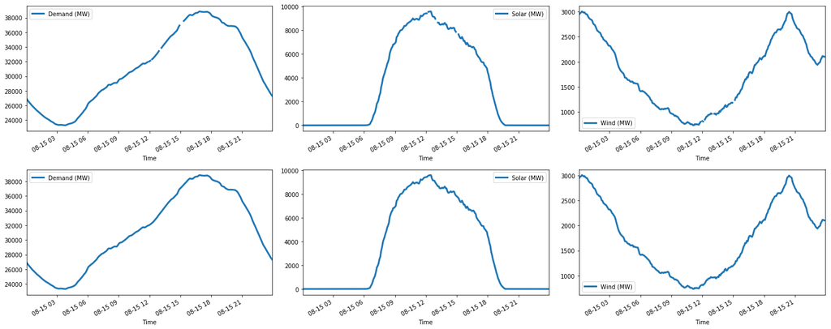

```python
start = '2018-08-15 00:00:00'
end   = '2018-08-16 00:00:00'

fig = plt.figure(figsize=(20,8))
ax = fig.add_subplot(231)
df[(df.Time > start) & (df.Time < end)].plot('Time','Demand (MW)',ax=ax, linewidth=3);
ax = fig.add_subplot(234)
CAISO[(CAISO.Time > start) & (CAISO.Time < end)].plot('Time','Demand (MW)',ax=ax, linewidth=3);

ax = fig.add_subplot(232)
df[(df.Time > start) & (df.Time < end)].plot('Time','Solar (MW)',ax=ax, linewidth=3);
ax = fig.add_subplot(235)
Solar[(Solar.Time > start) & (Solar.Time < end)].plot('Time','Solar (MW)',ax=ax, linewidth=3);

ax = fig.add_subplot(233)
df[(df.Time > start) & (df.Time < end)].plot('Time','Wind (MW)',ax=ax, linewidth=3);
ax = fig.add_subplot(236)
Wind[(Wind.Time > start) & (Wind.Time < end)].plot('Time','Wind (MW)',ax=ax, linewidth=3);

plt.tight_layout()
```

```python
# There are some gaps in the data, which can be observed in the top row of plots
# The following code fills those caps via interpolation

cols = ['Demand (MW)','Solar (MW)','Wind (MW)','Net Demand (MW)']

for col in cols:
    df[col].interpolate(method='linear', inplace=True)
```

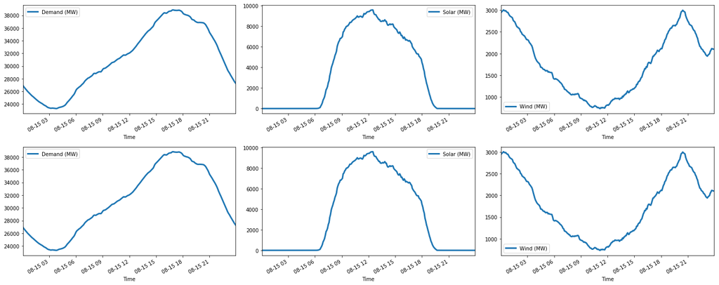

```python
# Re-plot to ensure gaps are filled appropriately

start = '2018-08-15 00:00:00'
end   = '2018-08-16 00:00:00'

fig = plt.figure(figsize=(20,8))
ax = fig.add_subplot(231)
df[(df.Time > start) & (df.Time < end)].plot('Time','Demand (MW)',ax=ax, linewidth=3);
ax = fig.add_subplot(234)
CAISO[(CAISO.Time > start) & (CAISO.Time < end)].plot('Time','Demand (MW)',ax=ax, linewidth=3);

ax = fig.add_subplot(232)
df[(df.Time > start) & (df.Time < end)].plot('Time','Solar (MW)',ax=ax, linewidth=3);
ax = fig.add_subplot(235)
Solar[(Solar.Time > start) & (Solar.Time < end)].plot('Time','Solar (MW)',ax=ax, linewidth=3);

ax = fig.add_subplot(233)
df[(df.Time > start) & (df.Time < end)].plot('Time','Wind (MW)',ax=ax, linewidth=3);
ax = fig.add_subplot(236)
Wind[(Wind.Time > start) & (Wind.Time < end)].plot('Time','Wind (MW)',ax=ax, linewidth=3);


plt.tight_layout()
```

# Assessment of energy in the CAISO region

Evaluate data to determine:

- Peak power demand
- Total energy demand in this time period
- Total energy from wind and solar, along with capacity factors
- Variability:
  - Hour-to-hour (intraday)
  - Day-to-day (within a month)
  - Seasonally (within the year)
  - Note that there may be some longer-term variations that are not captured in these data (*e.g.*, weather patterns that exist on a multi-year cycle, such as *$el$ $ni\tilde{n}o$*)

```python
p2e = 5/60 # conversion factor from instantaneous power to energy delivered over a 5 minute period
M2T = 1e6  # conversion factor to go from MWh to TWh

peak_demand  = df['Demand (MW)'].max()
total_energy = df['Demand (MW)'].sum()*p2e/M2T
wind_energy  = df['Wind (MW)'].sum()*p2e/M2T
solar_energy = df['Solar (MW)'].sum()*p2e/M2T
other_energy = total_energy - wind_energy - solar_energy

print('Peak power demand: {} MW'.format(peak_demand))
```

```
Peak power demand: 45616.0 MW
```

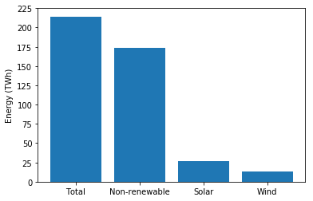

```python
labels = ['Total','Non-renewable','Solar','Wind']
energy = [total_energy, other_energy, solar_energy, wind_energy]
plt.bar(x=labels,height=energy);
plt.ylabel('Energy (TWh)');
```

```python
pct_solar = solar_energy / total_energy * 100
pct_wind  = wind_energy / total_energy * 100

print('Fraction of energy from solar: {}%'.format(round(pct_solar,1)))
print('Fraction of energy from wind:  {}%'.format(round(pct_wind,1)))
```

```
Fraction of energy from solar: 12.4%
Fraction of energy from wind:  6.3%
```

The above percentages are close to what was reported for generation in CA for 2018 (note that the data we are looking at here span mid-2018 to mid-2019):

- **Solar:** https://en.wikipedia.org/wiki/Solar_power_in_California
- **Wind:** https://en.wikipedia.org/wiki/Wind_power_in_California

The following installed capacities, which are current in CAISO as of July 11, 2019, are used to scale the generation data. It is assumed that this capacity has not changed in the past calendar year, which is a simplifying assumption:

- **Solar:** 12,049 MW
- **Wind:** 6,714 MW

```python
solar_capacity = 12049 # MW
wind_capacity  = 6714  # MW

solar_cap_factor = solar_energy * M2T / (8760 * solar_capacity)*100
wind_cap_factor  = wind_energy * M2T / (8760 * wind_capacity)*100

print('Solar Capacity Factor: {}%'.format(round(solar_cap_factor,1)))
print('Wind Capacity Factor:  {}%'.format(round(wind_cap_factor,1)))
```

```
Solar Capacity Factor: 25.2%
Wind Capacity Factor:  23.0%
```

```python
# Define variables that relate the amount of energy produced annually in terms of wind and solar installed capacity
solar_energy_perMW = solar_energy * M2T / solar_capacity
wind_energy_perMW = wind_energy * M2T / wind_capacity
```

```python
# Write function to add columns to facilitate plotting visualization

def net_energy_cols(df):
    df['Minus Wind (MW)']  = df['Demand (MW)'] - df['Wind (MW)']
    df['Minus Solar (MW)'] = df['Minus Wind (MW)'] - df['Solar (MW)']
    df['Net Demand (MW)']  = df['Minus Solar (MW)']
    return df

myFmt = mdates.DateFormatter('%H:%M',tz=pytz.timezone("US/Pacific"))

# Write function for plotting data
def energy_plot(df,start,end):
    x = df[(df.Time > start) & (df.Time < end)]

    plt.plot(x.Time,x['Minus Solar (MW)'], linewidth=3, color='gold');
    plt.fill_between(x.Time, x['Minus Wind (MW)'], x['Minus Solar (MW)'], facecolor='gold', alpha=0.2, interpolate=True)

    plt.plot(x.Time,x['Minus Wind (MW)'], linewidth=3, color='royalblue');
    plt.fill_between(x.Time, x['Demand (MW)'], x['Minus Wind (MW)'], facecolor='royalblue', alpha=0.2, interpolate=True)

    plt.plot(x.Time,x['Demand (MW)'], linewidth=3, color='black');
    plt.fill_between(x.Time, x['Net Demand (MW)'], 0, where=x['Net Demand (MW)']>0, facecolor='black',alpha=0.2, interpolate=True)

    ax.xaxis.set_major_formatter(myFmt)
    plt.axis([start, end,0,50000]);
```

```python
df = net_energy_cols(df)
```

The following series of plots show how demand varies hour-by-hour, day-by-day, and seasonally.

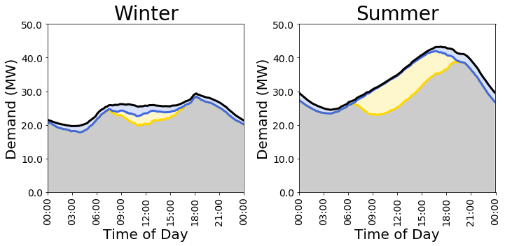

```python
# plot intraday data for each season

# Set timezone
tz     = pytz.timezone("US/Pacific")

# Pick a day for each season, choosing a Wednesday ~halfway through the season

summer = tz.localize(datetime(2018,8,8,0,0))   # August 8, 2018
fall   = tz.localize(datetime(2018,11,7,0,0))  # November 7, 2018
winter = tz.localize(datetime(2019,2,13,0,0))  # February 13, 2019
spring = tz.localize(datetime(2019,4,17,0,0))  # April 17, 2019

day    = timedelta(days=1)

fig = plt.figure(figsize=(20,5))

# dates = [winter, spring, summer ,fall]
# label = ['Winter','Spring','Summer', 'Fall']

dates = [winter, summer]
label = ['Winter','Summer']

i = 1
for d in dates:
    ax = fig.add_subplot(1,4,i)

    start = d
    end = d+day

    energy_plot(df,start,end)

    plt.xlim(dates[i-1],dates[i-1]+day)

    plt.ylim(0,50000)
    plt.title(label[i-1],fontsize=28)

    plt.xlabel('Time of Day',fontsize=20)
    plt.ylabel('Demand (MW)',fontsize=20)
    plt.xticks(rotation=90,fontsize=14)
    plt.yticks(fontsize=14)

    ax = plt.gca()
    ticks = ax.get_yticks()/(10**3)
    ax.set_yticklabels(ticks)

    i += 1

plt.tight_layout()
```

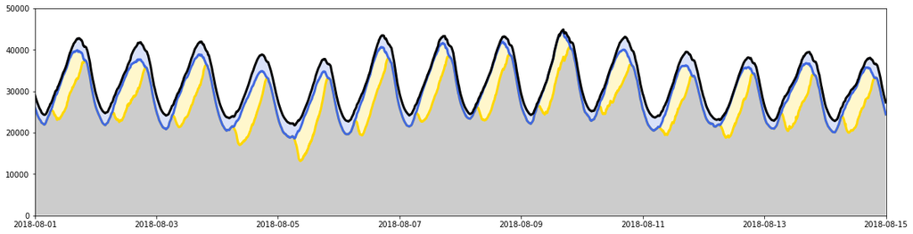

```python
# plot intraday data for a couple weeks month in August 2018

start = tz.localize(datetime(2018, 8, 1, 0, 0)) # August 1, 2018
end   = start + timedelta(days=14)

fig = plt.figure(figsize=(20,5))

energy_plot(df,start,end)

plt.axis([start, end,0,50000]);
```

```python
df
```

|  | Time | Demand (MW) | Wind (MW) | Solar (MW) | Net Demand (MW) | Minus Wind (MW) | Minus Solar (MW) |
| --- | --- | --- | --- | --- | --- | --- | --- |
| 0 | 2018-07-01 00:00:00-07:00 | 24860.0 | 3554.50 | 0.89 | 21304.61 | 21305.50 | 21304.61 |
| 1 | 2018-07-01 00:05:00-07:00 | 24707.0 | 3537.95 | 0.89 | 21168.16 | 21169.05 | 21168.16 |
| 2 | 2018-07-01 00:10:00-07:00 | 24587.0 | 3536.02 | 0.89 | 21050.09 | 21050.98 | 21050.09 |
| 3 | 2018-07-01 00:15:00-07:00 | 24444.0 | 3524.82 | 0.89 | 20918.29 | 20919.18 | 20918.29 |
| 4 | 2018-07-01 00:20:00-07:00 | 24287.0 | 3529.88 | 0.89 | 20756.23 | 20757.12 | 20756.23 |
| 5 | 2018-07-01 00:25:00-07:00 | 24139.0 | 3513.20 | 0.89 | 20624.91 | 20625.80 | 20624.91 |
| 6 | 2018-07-01 00:30:00-07:00 | 23994.0 | 3484.56 | 0.88 | 20508.56 | 20509.44 | 20508.56 |
| 7 | 2018-07-01 00:35:00-07:00 | 23851.0 | 3480.14 | 0.88 | 20369.98 | 20370.86 | 20369.98 |
| 8 | 2018-07-01 00:40:00-07:00 | 23718.0 | 3485.67 | 0.88 | 20231.45 | 20232.33 | 20231.45 |
| 9 | 2018-07-01 00:45:00-07:00 | 23590.0 | 3480.88 | 0.88 | 20108.24 | 20109.12 | 20108.24 |
| 10 | 2018-07-01 00:50:00-07:00 | 23553.0 | 3477.24 | 0.88 | 20074.88 | 20075.76 | 20074.88 |
| 11 | 2018-07-01 00:55:00-07:00 | 23462.0 | 3480.39 | 0.88 | 19980.73 | 19981.61 | 19980.73 |
| 12 | 2018-07-01 01:00:00-07:00 | 23329.0 | 3464.59 | 0.88 | 19863.53 | 19864.41 | 19863.53 |
| 13 | 2018-07-01 01:05:00-07:00 | 23200.0 | 3422.85 | 0.88 | 19776.27 | 19777.15 | 19776.27 |
| 14 | 2018-07-01 01:10:00-07:00 | 23093.0 | 3376.72 | 0.88 | 19715.40 | 19716.28 | 19715.40 |
| 15 | 2018-07-01 01:15:00-07:00 | 22983.0 | 3334.45 | 0.88 | 19647.67 | 19648.55 | 19647.67 |
| 16 | 2018-07-01 01:20:00-07:00 | 22871.0 | 3321.66 | 0.87 | 19548.47 | 19549.34 | 19548.47 |
| 17 | 2018-07-01 01:25:00-07:00 | 22770.0 | 3336.20 | 0.87 | 19432.93 | 19433.80 | 19432.93 |
| 18 | 2018-07-01 01:30:00-07:00 | 22674.0 | 3385.67 | 0.87 | 19287.46 | 19288.33 | 19287.46 |
| 19 | 2018-07-01 01:35:00-07:00 | 22579.0 | 3396.15 | 0.87 | 19181.98 | 19182.85 | 19181.98 |
| 20 | 2018-07-01 01:40:00-07:00 | 22491.0 | 3423.07 | 0.87 | 19067.06 | 19067.93 | 19067.06 |
| 21 | 2018-07-01 01:45:00-07:00 | 22406.0 | 3442.88 | 0.87 | 18962.25 | 18963.12 | 18962.25 |
| 22 | 2018-07-01 01:50:00-07:00 | 22322.0 | 3488.16 | 0.88 | 18832.96 | 18833.84 | 18832.96 |
| 23 | 2018-07-01 01:55:00-07:00 | 22245.0 | 3528.61 | 0.88 | 18715.51 | 18716.39 | 18715.51 |
| 24 | 2018-07-01 02:00:00-07:00 | 22172.0 | 3540.22 | 0.88 | 18630.90 | 18631.78 | 18630.90 |
| 25 | 2018-07-01 02:05:00-07:00 | 22097.0 | 3479.75 | 0.89 | 18616.36 | 18617.25 | 18616.36 |
| 26 | 2018-07-01 02:10:00-07:00 | 22015.0 | 3469.95 | 0.90 | 18544.15 | 18545.05 | 18544.15 |
| 27 | 2018-07-01 02:15:00-07:00 | 21936.0 | 3419.55 | 0.93 | 18515.52 | 18516.45 | 18515.52 |
| 28 | 2018-07-01 02:20:00-07:00 | 21863.0 | 3372.10 | 0.94 | 18489.96 | 18490.90 | 18489.96 |
| 29 | 2018-07-01 02:25:00-07:00 | 21779.0 | 3377.47 | 0.94 | 18400.59 | 18401.53 | 18400.59 |
| ... | ... | ... | ... | ... | ... | ... | ... |
| 105090 | 2019-06-30 21:30:00-07:00 | 28304.0 | 3318.56 | 0.00 | 24985.44 | 24985.44 | 24985.44 |
| 105091 | 2019-06-30 21:35:00-07:00 | 28112.0 | 3312.33 | 0.00 | 24799.67 | 24799.67 | 24799.67 |
| 105092 | 2019-06-30 21:40:00-07:00 | 27927.0 | 3348.63 | 0.00 | 24578.37 | 24578.37 | 24578.37 |
| 105093 | 2019-06-30 21:45:00-07:00 | 27758.0 | 3313.50 | 0.00 | 24444.50 | 24444.50 | 24444.50 |
| 105094 | 2019-06-30 21:50:00-07:00 | 27580.0 | 3323.79 | 0.00 | 24256.21 | 24256.21 | 24256.21 |
| 105095 | 2019-06-30 21:55:00-07:00 | 27386.0 | 3287.19 | 0.00 | 24098.81 | 24098.81 | 24098.81 |
| 105096 | 2019-06-30 22:00:00-07:00 | 27168.0 | 3291.57 | 0.00 | 23876.43 | 23876.43 | 23876.43 |
| 105097 | 2019-06-30 22:05:00-07:00 | 26985.0 | 3314.92 | 0.00 | 23670.08 | 23670.08 | 23670.08 |
| 105098 | 2019-06-30 22:10:00-07:00 | 26796.0 | 3335.76 | 0.00 | 23460.24 | 23460.24 | 23460.24 |
| 105099 | 2019-06-30 22:15:00-07:00 | 26603.0 | 3332.40 | 0.00 | 23270.60 | 23270.60 | 23270.60 |
| 105100 | 2019-06-30 22:20:00-07:00 | 26432.0 | 3382.23 | 0.00 | 23049.77 | 23049.77 | 23049.77 |
| 105101 | 2019-06-30 22:25:00-07:00 | 26245.0 | 3407.29 | 0.00 | 22837.71 | 22837.71 | 22837.71 |
| 105102 | 2019-06-30 22:30:00-07:00 | 26049.0 | 3399.40 | 0.00 | 22649.60 | 22649.60 | 22649.60 |
| 105103 | 2019-06-30 22:35:00-07:00 | 25851.0 | 3406.42 | 0.00 | 22444.58 | 22444.58 | 22444.58 |
| 105104 | 2019-06-30 22:40:00-07:00 | 25645.0 | 3430.97 | 0.00 | 22214.03 | 22214.03 | 22214.03 |
| 105105 | 2019-06-30 22:45:00-07:00 | 25437.0 | 3465.96 | 0.00 | 21971.04 | 21971.04 | 21971.04 |
| 105106 | 2019-06-30 22:50:00-07:00 | 25238.0 | 3528.12 | 0.00 | 21709.88 | 21709.88 | 21709.88 |
| 105107 | 2019-06-30 22:55:00-07:00 | 25047.0 | 3575.00 | 0.00 | 21472.00 | 21472.00 | 21472.00 |
| 105108 | 2019-06-30 23:00:00-07:00 | 24803.0 | 3581.01 | 0.00 | 21221.99 | 21221.99 | 21221.99 |
| 105109 | 2019-06-30 23:05:00-07:00 | 24540.0 | 3611.71 | 0.00 | 20928.29 | 20928.29 | 20928.29 |
| 105110 | 2019-06-30 23:10:00-07:00 | 24322.0 | 3624.44 | 0.00 | 20697.56 | 20697.56 | 20697.56 |
| 105111 | 2019-06-30 23:15:00-07:00 | 24102.0 | 3647.82 | 0.00 | 20454.18 | 20454.18 | 20454.18 |
| 105112 | 2019-06-30 23:20:00-07:00 | 23878.0 | 3649.86 | 0.00 | 20228.14 | 20228.14 | 20228.14 |
| 105113 | 2019-06-30 23:25:00-07:00 | 23690.0 | 3666.89 | 0.00 | 20023.11 | 20023.11 | 20023.11 |
| 105114 | 2019-06-30 23:30:00-07:00 | 23509.0 | 3691.18 | 0.00 | 19817.82 | 19817.82 | 19817.82 |
| 105115 | 2019-06-30 23:35:00-07:00 | 23324.0 | 3721.33 | 0.00 | 19602.67 | 19602.67 | 19602.67 |
| 105116 | 2019-06-30 23:40:00-07:00 | 23157.0 | 3753.91 | 0.00 | 19403.09 | 19403.09 | 19403.09 |
| 105117 | 2019-06-30 23:45:00-07:00 | 23003.0 | 3787.65 | 0.00 | 19215.35 | 19215.35 | 19215.35 |
| 105118 | 2019-06-30 23:50:00-07:00 | 22856.0 | 3798.13 | 0.00 | 19057.87 | 19057.87 | 19057.87 |
| 105119 | 2019-06-30 23:55:00-07:00 | 22693.0 | 3818.04 | 0.00 | 18874.96 | 18874.96 | 18874.96 |

105120 rows × 7 columns

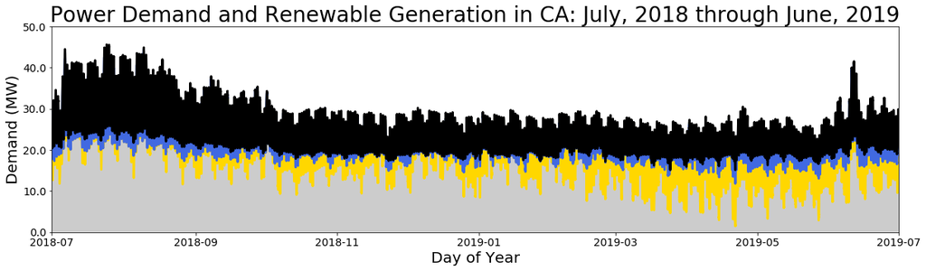

```python
# plot data for the whole year

start = tz.localize(datetime(2018, 7, 1, 0, 0)) # July 1, 2018
end   = start + timedelta(days=365)

fig = plt.figure(figsize=(20,5))

energy_plot(df,start,end)

plt.title('Power Demand and Renewable Generation in CA: July, 2018 through June, 2019', fontsize=28)
plt.xlabel('Day of Year',fontsize=20)
plt.ylabel('Demand (MW)',fontsize=20)
plt.xticks(fontsize=14)
plt.yticks(fontsize=14)

ax = plt.gca()
ticks = ax.get_yticks()/(10**3)
ax.set_yticklabels(ticks)

plt.axis([start, end,0,50000]);
```

# How much energy needs to be shifted and by how long?

In this section, we'll scale the production of renewables to determine how much energy would need to be shifted and by how long. As part of this analysis, we'll also take a look at the optimal blend of renewables on the grid, *i.e.* to minemize the amount of shifting required. This will proceed using the following approach (psuedo-code):

- Set a desired amount of energy that must come from renewables
- Determine how much energy needs to be shifted for an array of wind / solar compositions
- Determine the minimum amount of time that each packet of energy needs to be shifted
- Assume the data are static and periodic within the year so the beginning of the data set (*i.e.*, where renewable generation is relatively low) can draw from data toward the end of the dataset, where renewable generation is higher.

Let's start by looking at what generation curves would look like for a hand-picked day in the Spring if all of the energy for that day were to come from renewables (first wind and solar separately, then a 50/50 mix).

```python
# To start, we need to define a few new dataframes that support these mixes
# To do this, the wind and solar columns will be scaled by total installed capacity

# Dataframe that assumes wind only
df_wind = df[['Time','Demand (MW)','Wind (MW)','Solar (MW)']].copy()
df_wind['Wind (MW)'] = df_wind['Wind (MW)'] / wind_capacity
df_wind['Solar (MW)'] = 0

# Dataframe that assumes solar only
df_solar = df[['Time','Demand (MW)','Wind (MW)','Solar (MW)']].copy()
df_solar['Solar (MW)'] = df_solar['Solar (MW)'] / solar_capacity
df_solar['Wind (MW)'] = 0

# Dataframe that assumes a 50/50 mix of solar and wind
df_both = df[['Time','Demand (MW)','Wind (MW)','Solar (MW)']].copy()
df_both['Solar (MW)'] = df_both['Solar (MW)'] / solar_capacity
df_both['Wind (MW)'] = df_both['Wind (MW)'] / wind_capacity
```

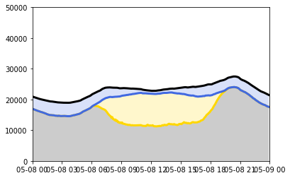

```python
# Plot original data for May 8, 2019

start = tz.localize(datetime(2019, 5, 8, 0, 0)) # May 8, 2019
end   = start + timedelta(days=1)

energy_plot(df,start,end)
```

```python
# grab total amount of energy for the day shown above, converted to TWh
e_total = df[(df.Time > start) & (df.Time < end)]['Demand (MW)'].sum() * p2e / M2T
e_solar = df_solar[(df_solar.Time > start) & (df_solar.Time < end)]['Solar (MW)'].sum() * p2e / M2T
e_wind  = df_wind[(df_wind.Time > start) & (df_wind.Time < end)]['Wind (MW)'].sum() * p2e / M2T
e_both  = e_solar + e_wind

# create iterable for fraction of energy to come from renewables
pct_renewable = np.linspace(0.25,1,4)
```

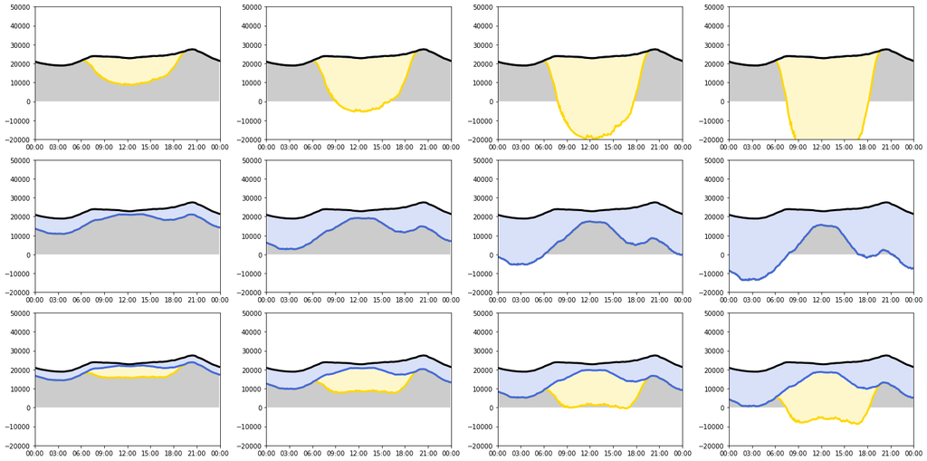

```python
fig = plt.figure(figsize=(20,10))

i = 1

for p in pct_renewable:
    s = p * e_total / e_solar
    w = p * e_total / e_wind
    b = p * e_total / e_both

    df_solar['Solar (MW)'] *= s
    df_solar = net_energy_cols(df_solar)
    ax = fig.add_subplot(3,4,i)
    energy_plot(df_solar,start,end)
    df_solar['Solar (MW)'] *= 1/s
    plt.axis([start, end,-20000,50000]);

    df_wind['Wind (MW)'] *= w
    df_wind = net_energy_cols(df_wind)
    ax = fig.add_subplot(3,4,i+4)
    energy_plot(df_wind,start,end)
    df_wind['Wind (MW)'] *= 1/w
    plt.axis([start, end,-20000,50000]);

    df_both['Solar (MW)'] *= b
    df_both['Wind (MW)'] *= b
    df_both = net_energy_cols(df_both)
    ax = fig.add_subplot(3,4,i+8)
    energy_plot(df_both,start,end)
    df_both['Solar (MW)'] *= 1/b
    df_both['Wind (MW)'] *= 1/b
    plt.axis([start, end,-20000,50000]);

    i+=1

plt.tight_layout()
```

Next, we'll want to look at how much energy needs to be shifted, and by how far. In doing so, we'll also solve for the optimal mix of renewables on the grid at a given renewable adoption rate. As an initial pass, it is assumed that both wind and solar are the same cost (which is roughly true right now, at $1/W installed), thus this assessment is made based on capacity, rather than explicitly on capital.

Psuedo code:

```python
# Define function to determine the optimal mix of renewables on the grid for a given reneable penetration
def opt_mix(x_renewables,df_temp):

    # adjust the mix of wind and solar
    pct_solar  = np.linspace(0,1,101)

    excess = []

    for solar in pct_solar:

        scaler = energy_total * x_renewables / (solar * energy_solar + (1-solar) * energy_wind)

        df_temp['Solar (MW)'] = df_temp['Solar (MW) Base'] * scaler * solar
        df_temp['Wind (MW)']  = df_temp['Wind (MW) Base'] * scaler * (1-solar)

        df_temp = net_energy_cols(df_temp)

        excess.append(df_temp[df_temp['Net Demand (MW)'] < 0].sum()['Net Demand (MW)'])

    return excess
```

```python
# Working dataframe with solar and wind output normalized by capacity
# (i.e., solar and wind values indicated MW of power output per MW of installed capacity)

df_temp = df[['Time', 'Demand (MW)', 'Wind (MW)', 'Solar (MW)']].copy()
df_temp['Solar (MW) Base'] = df['Solar (MW)'] / solar_capacity
df_temp['Wind (MW) Base'] = df['Wind (MW)'] / wind_capacity

energy_total = df_temp['Demand (MW)'].sum()
energy_solar = df_temp['Solar (MW) Base'].sum() # total solar power normalized by installed capacity
energy_wind  = df_temp['Wind (MW) Base'].sum() # total wind power normalized by installed capacity

pcts = np.linspace(0,1,21)

overgen = []

n = 1

for p in pcts:
    start = time.time()

    overgen.append(opt_mix(p,df_temp))

    t = time.time()-start
    m = int(t//60)
    s = int(t-m*60)
    print("Iteration {} of {} complete.  Runtime: {}".format(n,len(pcts),(str(m)+':'+str.rjust(str(s),2,'0'))))

    n+=1
```

```
Iteration 1 of 21 complete.  Runtime: 0:02
Iteration 2 of 21 complete.  Runtime: 0:02
Iteration 3 of 21 complete.  Runtime: 0:03
Iteration 4 of 21 complete.  Runtime: 0:02
Iteration 5 of 21 complete.  Runtime: 0:01
Iteration 6 of 21 complete.  Runtime: 0:02
Iteration 7 of 21 complete.  Runtime: 0:06
Iteration 8 of 21 complete.  Runtime: 0:09
Iteration 9 of 21 complete.  Runtime: 0:17
Iteration 10 of 21 complete.  Runtime: 0:23
Iteration 11 of 21 complete.  Runtime: 0:38
Iteration 12 of 21 complete.  Runtime: 0:44
Iteration 13 of 21 complete.  Runtime: 0:42
Iteration 14 of 21 complete.  Runtime: 0:52
Iteration 15 of 21 complete.  Runtime: 0:56
Iteration 16 of 21 complete.  Runtime: 1:15
Iteration 17 of 21 complete.  Runtime: 1:39
Iteration 18 of 21 complete.  Runtime: 1:10
Iteration 19 of 21 complete.  Runtime: 1:17
Iteration 20 of 21 complete.  Runtime: 1:23
Iteration 21 of 21 complete.  Runtime: 1:24
```

```python
overgen  = np.asarray(overgen)
overgen *= -1
overgen  = overgen * p2e / M2T
```

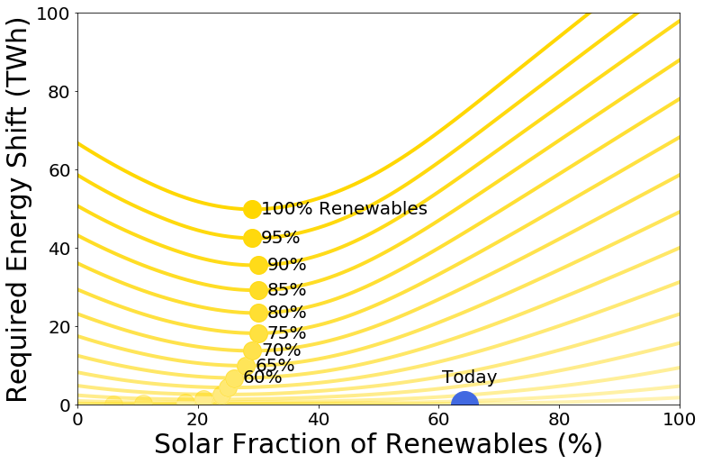

```python
x = np.linspace(0,100,101)

lines = np.shape(overgen)[0]

alpha = np.linspace(0,1,lines)

plt.figure(figsize=(12,8))
for l in range(6,lines):
    xmin = overgen[l].argmin()
    ymin = overgen[l][overgen[l].argmin()]
    plt.plot(x,overgen[l],color = 'gold',alpha = alpha[l],linewidth=4)
    plt.plot(xmin,ymin,'o',color='white',ms=20)
    plt.plot(xmin,ymin,'o',color='gold',ms=20,alpha=alpha[l])

    if l == 20:
        plt.annotate('100% Renewables',
                     xy=(xmin,ymin),
                     xycoords='data',
                     xytext=(10,-5),
                     textcoords='offset points',
                     fontsize=20)
    elif l>11:
        plt.annotate(str(int(l*10/2))+'%',
                     xy=(xmin,ymin),
                     xycoords='data',
                     xytext=(10,-5),
                     textcoords='offset points',
                     fontsize=20)


today = 100*solar_capacity/(solar_capacity+wind_capacity)
plt.plot(today,0,'o',color='royalblue',ms=30)
plt.annotate('Today',
             xy=(today,0),
             xycoords='data',
             xytext=(-25,25),
             textcoords='offset points',
             fontsize=20)

plt.xlabel('Solar Fraction of Renewables (%)',fontsize=30)
plt.xticks(fontsize=20)
plt.ylabel('Required Energy Shift (TWh)',fontsize=30)
plt.yticks(fontsize=20)
plt.axis([0,100,0,100]);
```

```
[0, 100, 0, 50]
```

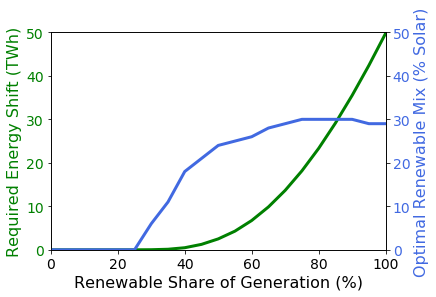

```python
opt_solar = []
shift     = []
pct_ren = np.linspace(0,100,21)

for i in range(np.shape(overgen)[0]):
    lst = list(overgen[i])
    opt_solar.append(lst.index(min(lst)))
    shift.append(overgen[i].min())

fig, ax1 = plt.subplots(figsize=(6,4))

color = 'green'
ax1.set_xlabel('Renewable Share of Generation (%)',fontsize=16)
ax1.tick_params(labelsize=14)
ax1.set_ylabel('Required Energy Shift (TWh)',fontsize=16,color=color)
ax1.plot(pct_ren,shift,color=color,linewidth=3)
ax1.tick_params(axis='y', labelcolor=color)
plt.axis([0,100,0,50])


ax2 = ax1.twinx()

color = 'royalblue'
ax2.tick_params(labelsize=14)
ax2.set_ylabel('Optimal Renewable Mix (% Solar)',fontsize=16,color=color)
ax2.plot(pct_ren,opt_solar,color=color,linewidth=3)
ax2.tick_params(axis='y', labelcolor=color)
plt.axis([0,100,0,50])
```

```python
df_temp = df[['Time', 'Demand (MW)', 'Wind (MW)', 'Solar (MW)']].copy()
df_temp['Solar (MW) Base'] = df['Solar (MW)'] / solar_capacity
df_temp['Wind (MW) Base'] = df['Wind (MW)'] / wind_capacity

energy_total = df_temp['Demand (MW)'].sum()
energy_solar = df_temp['Solar (MW) Base'].sum() # total solar power normalized by installed capacity
energy_wind  = df_temp['Wind (MW) Base'].sum() # total wind power normalized by installed capacity
```

```python
# Define function to determine how much energy needs to be shifted and by how long
def storage(df_temp,x_renewables,x_solar):

    scaler = energy_total * x_renewables / (x_solar * energy_solar + (1-x_solar) * energy_wind)

    df_temp['Solar (MW)'] = df_temp['Solar (MW) Base'] * scaler * x_solar
    df_temp['Wind (MW)']  = df_temp['Wind (MW) Base'] * scaler * (1-x_solar)

    df_temp = df_temp.groupby(df_temp.index // 12).sum()

    df_temp = net_energy_cols(df_temp)

    df_shift = pd.DataFrame(columns = ['Excess','Shortage'])
    df_shift['Temp'] = np.linspace(0,0,df_temp.shape[0]).astype(int)

    df_shift['Excess']   = -1*df_temp[df_temp['Net Demand (MW)'] < 0]['Net Demand (MW)']
    df_shift['Shortage'] = df_temp[df_temp['Net Demand (MW)'] > 0]['Net Demand (MW)']
    df_shift.fillna(0,inplace=True)


    time_shifted = 0
    results = []

    n = 0

    while df_shift['Excess'].sum() > 1:

        wrap = df_shift.iloc[-1]['Excess']
        df_shift['Excess'] = df_shift['Excess'].shift(periods=1)
        df_shift['Excess'].loc[0] = wrap
        df_shift['Temp'] = df_shift.loc[:, ['Excess', 'Shortage']].min(axis=1)

        time_shifted += 5
        energy_shifted = df_shift['Temp'].sum()
        results.append((time_shifted,energy_shifted))

        df_shift['Excess'] = df_shift['Excess'] - df_shift['Temp']
        df_shift['Shortage'] = df_shift['Shortage'] - df_shift['Temp']
        df_shift['Temp'] = 0

        n+=1

        if n%100 == 0:
            print('Periods Shifted: {}     Energy Shift Remaining: {} TWh'.format(n,round(df_shift['Excess'].sum()*p2e/M2T,1)))


    return results
```

# Note to Reviewer:

The following block of code took several hours to run on my local machine. If you are executing the code to ensure that it works, I recommend skipping the next three blocks, which calculate how much energy needs to be shifted and for how long and then stores the result into a csv file. Once this routine is complete, the csv file is re-loaded to continue the analysis, so you may want to skip to that block of code, below, to streamline the process on your end.

```python
results = []

n = 1

for i in range(len(pcts)):
    start = time.time()

    results.append(storage(df_temp,pcts[i],opt_solar[i]/100))

    t = time.time()-start
    m = int(t//60)
    s = int(t-m*60)
    print("Iteration {} of {} complete.  Runtime: {}".format(n,len(pcts),(str(m)+':'+str.rjust(str(s),2,'0'))))

    n+=1
```

```
Iteration 1 of 21 complete.  Runtime: 0:00
Iteration 2 of 21 complete.  Runtime: 0:00
Iteration 3 of 21 complete.  Runtime: 0:00
Iteration 4 of 21 complete.  Runtime: 0:00
Iteration 5 of 21 complete.  Runtime: 0:00
Iteration 6 of 21 complete.  Runtime: 0:00
Iteration 7 of 21 complete.  Runtime: 0:05
Iteration 8 of 21 complete.  Runtime: 0:10
Iteration 9 of 21 complete.  Runtime: 0:21
Iteration 10 of 21 complete.  Runtime: 0:38
Periods Shifted: 100     Energy Shift Remaining: 0.0 TWh
Iteration 11 of 21 complete.  Runtime: 1:08
Periods Shifted: 100     Energy Shift Remaining: 0.2 TWh
Iteration 12 of 21 complete.  Runtime: 1:40
Periods Shifted: 100     Energy Shift Remaining: 1.0 TWh
Periods Shifted: 200     Energy Shift Remaining: 0.5 TWh
Periods Shifted: 300     Energy Shift Remaining: 0.1 TWh
Iteration 13 of 21 complete.  Runtime: 3:18
Periods Shifted: 100     Energy Shift Remaining: 2.4 TWh
Periods Shifted: 200     Energy Shift Remaining: 1.8 TWh
Periods Shifted: 300     Energy Shift Remaining: 1.5 TWh
Periods Shifted: 400     Energy Shift Remaining: 1.0 TWh
Periods Shifted: 500     Energy Shift Remaining: 0.7 TWh
Periods Shifted: 600     Energy Shift Remaining: 0.5 TWh
Periods Shifted: 700     Energy Shift Remaining: 0.5 TWh
Periods Shifted: 800     Energy Shift Remaining: 0.4 TWh
Periods Shifted: 900     Energy Shift Remaining: 0.1 TWh
Periods Shifted: 1000     Energy Shift Remaining: 0.1 TWh
Iteration 14 of 21 complete.  Runtime: 10:14
Periods Shifted: 100     Energy Shift Remaining: 4.8 TWh
Periods Shifted: 200     Energy Shift Remaining: 4.2 TWh
Periods Shifted: 300     Energy Shift Remaining: 3.8 TWh
Periods Shifted: 400     Energy Shift Remaining: 3.5 TWh
Periods Shifted: 500     Energy Shift Remaining: 3.2 TWh
Periods Shifted: 600     Energy Shift Remaining: 2.2 TWh
Periods Shifted: 700     Energy Shift Remaining: 1.9 TWh
Periods Shifted: 800     Energy Shift Remaining: 1.9 TWh
Periods Shifted: 900     Energy Shift Remaining: 1.4 TWh
Periods Shifted: 1000     Energy Shift Remaining: 1.4 TWh
Periods Shifted: 1100     Energy Shift Remaining: 1.4 TWh
```

[output cut: 334 more lines]

```
Periods Shifted: 7400     Energy Shift Remaining: 1.3 TWh
Periods Shifted: 7500     Energy Shift Remaining: 0.9 TWh
Periods Shifted: 7600     Energy Shift Remaining: 0.9 TWh
Periods Shifted: 7700     Energy Shift Remaining: 0.7 TWh
Periods Shifted: 7800     Energy Shift Remaining: 0.6 TWh
Periods Shifted: 7900     Energy Shift Remaining: 0.3 TWh
Periods Shifted: 8000     Energy Shift Remaining: 0.1 TWh
Periods Shifted: 8100     Energy Shift Remaining: 0.1 TWh
Periods Shifted: 8200     Energy Shift Remaining: 0.1 TWh
Periods Shifted: 8300     Energy Shift Remaining: 0.1 TWh
Periods Shifted: 8400     Energy Shift Remaining: 0.1 TWh
Periods Shifted: 8500     Energy Shift Remaining: 0.1 TWh
Periods Shifted: 8600     Energy Shift Remaining: 0.0 TWh
Periods Shifted: 8700     Energy Shift Remaining: 0.0 TWh
Iteration 21 of 21 complete.  Runtime: 104:04
```

```python
# Create dataframe to track results
frac_renewables = np.linspace(0,1,21)

df_shift = pd.DataFrame(columns = ['Time Shifted (hrs)'])

for p in frac_renewables:
    column = str(int(round(100*p))) + '% Renewables'
    df_shift[column] = np.linspace(1,8760,8760)*np.nan

df_shift['Time Shifted (hrs)'] = np.linspace(1,8760,8760).astype(int)
df_shift.fillna(0,inplace=True)

cols = list(df_shift.columns)[1:]

for j in range(len(results)):
    y = []
    for i in results[j]:
        y.append(i[1] * p2e / M2T)
    df_shift[cols[j]].iloc[0:len(y)] = y
```

```python
df_shift.to_csv('Results.csv',index=False)
```

# Reload save results

```python
df_shift = pd.read_csv('Results.csv')
```

```python
df_shift.head()
```

|  | Time Shifted (hrs) | 0% Renewables | 5% Renewables | 10% Renewables | 15% Renewables | 20% Renewables | 25% Renewables | 30% Renewables | 35% Renewables | 40% Renewables | ... | 55% Renewables | 60% Renewables | 65% Renewables | 70% Renewables | 75% Renewables | 80% Renewables | 85% Renewables | 90% Renewables | 95% Renewables | 100% Renewables |
| --- | --- | --- | --- | --- | --- | --- | --- | --- | --- | --- | --- | --- | --- | --- | --- | --- | --- | --- | --- | --- | --- |
| 0 | 1 | 0.0 | 0.0 | 0.0 | 0.0 | 0.0 | 0.0 | 0.002276 | 0.012355 | 0.023533 | ... | 0.122878 | 0.181412 | 0.219521 | 0.281102 | 0.339177 | 0.393891 | 0.388303 | 0.391800 | 0.420108 | 0.440092 |
| 1 | 2 | 0.0 | 0.0 | 0.0 | 0.0 | 0.0 | 0.0 | 0.001408 | 0.007650 | 0.038084 | ... | 0.207802 | 0.238569 | 0.354181 | 0.433399 | 0.500998 | 0.511479 | 0.634449 | 0.688075 | 0.618718 | 0.619386 |
| 2 | 3 | 0.0 | 0.0 | 0.0 | 0.0 | 0.0 | 0.0 | 0.005949 | 0.016026 | 0.041071 | ... | 0.220410 | 0.334448 | 0.378949 | 0.475360 | 0.605505 | 0.692591 | 0.633820 | 0.673879 | 0.761932 | 0.782558 |
| 3 | 4 | 0.0 | 0.0 | 0.0 | 0.0 | 0.0 | 0.0 | 0.002563 | 0.010827 | 0.042459 | ... | 0.227953 | 0.283010 | 0.392629 | 0.515208 | 0.576592 | 0.609204 | 0.705038 | 0.741658 | 0.721928 | 0.782127 |
| 4 | 5 | 0.0 | 0.0 | 0.0 | 0.0 | 0.0 | 0.0 | 0.003266 | 0.012167 | 0.049778 | ... | 0.225708 | 0.283942 | 0.368225 | 0.436126 | 0.564518 | 0.617106 | 0.664913 | 0.723370 | 0.682513 | 0.706048 |

5 rows × 22 columns

```python
df_duration = pd.DataFrame(columns = ['Time Shifted (hrs)'])

frac_renewables = np.linspace(0,1,21)
cols = list(df_shift.columns)[1:]

for p in frac_renewables:
    column = str(int(round(100*p))) + '% Renewables'
    df_duration[column] = np.linspace(0,5,6)*np.nan

df_duration.fillna(0,inplace=True)

sum_lims = [0,2,4,10,100,1000]

i = 0

for col in df_duration.columns[1:]:
    for i in range(len(sum_lims)):
        if i == len(sum_lims)-1:
            total_shift = df_shift[col].iloc[sum_lims[i]:].sum()
            df_duration[col].iloc[i] = total_shift
        else:
            total_shift = df_shift[col].iloc[sum_lims[i]:sum_lims[i+1]].sum()
            df_duration[col].iloc[i] = total_shift
    print(col, 'column complete.')
```

```
0% Renewables column complete.
5% Renewables column complete.
10% Renewables column complete.
15% Renewables column complete.
20% Renewables column complete.
25% Renewables column complete.
30% Renewables column complete.
35% Renewables column complete.
40% Renewables column complete.
45% Renewables column complete.
50% Renewables column complete.
55% Renewables column complete.
60% Renewables column complete.
65% Renewables column complete.
70% Renewables column complete.
75% Renewables column complete.
80% Renewables column complete.
85% Renewables column complete.
90% Renewables column complete.
95% Renewables column complete.
100% Renewables column complete.
```

```python
df_duration = df_duration[cols].transpose()
df_duration.columns = ['0-2 hours','2-4 hours','4-10 hours','10-100 hours','100-1000 hours','1000+ hours']
df_duration.index = [str(i*5)+'%' for i in range(21)]
df_duration
```

|  | 0-2 hours | 2-4 hours | 4-10 hours | 10-100 hours | 100-1000 hours | 1000+ hours |
| --- | --- | --- | --- | --- | --- | --- |
| 0% | 0.000000 | 0.000000 | 0.000000 | 0.000000 | 0.000000 | 0.000000 |
| 5% | 0.000000 | 0.000000 | 0.000000 | 0.000000 | 0.000000 | 0.000000 |
| 10% | 0.000000 | 0.000000 | 0.000000 | 0.000000 | 0.000000 | 0.000000 |
| 15% | 0.000000 | 0.000000 | 0.000000 | 0.000000 | 0.000000 | 0.000000 |
| 20% | 0.000000 | 0.000000 | 0.000000 | 0.000000 | 0.000000 | 0.000000 |
| 25% | 0.000000 | 0.000000 | 0.000000 | 0.000000 | 0.000000 | 0.000000 |
| 30% | 0.003684 | 0.008512 | 0.008116 | 0.000000 | 0.000000 | 0.000000 |
| 35% | 0.020005 | 0.026853 | 0.053789 | 0.022561 | 0.000000 | 0.000000 |
| 40% | 0.061617 | 0.083530 | 0.189825 | 0.129713 | 0.000000 | 0.000000 |
| 45% | 0.129113 | 0.193927 | 0.439241 | 0.465039 | 0.000000 | 0.000000 |
| 50% | 0.227316 | 0.341359 | 0.712655 | 1.166494 | 0.021890 | 0.000000 |
| 55% | 0.330680 | 0.448363 | 0.872015 | 2.387771 | 0.193881 | 0.000000 |
| 60% | 0.419981 | 0.617459 | 1.128750 | 3.522425 | 0.972924 | 0.000000 |
| 65% | 0.573701 | 0.771577 | 1.505013 | 4.467037 | 2.383907 | 0.064687 |
| 70% | 0.714501 | 0.990568 | 1.823777 | 5.255780 | 3.354971 | 1.403157 |
| 75% | 0.840175 | 1.182097 | 2.373078 | 5.996968 | 3.527404 | 4.102274 |
| 80% | 0.905370 | 1.301794 | 2.737087 | 7.166340 | 4.239674 | 6.823337 |
| 85% | 1.022752 | 1.338858 | 3.069418 | 8.448145 | 4.762784 | 10.331430 |
| 90% | 1.079875 | 1.415537 | 3.252812 | 9.419236 | 5.617612 | 14.538844 |
| 95% | 1.038826 | 1.483859 | 3.294435 | 10.240887 | 6.718332 | 19.442172 |
| 100% | 1.059479 | 1.564684 | 3.443908 | 10.768158 | 7.494821 | 25.253526 |

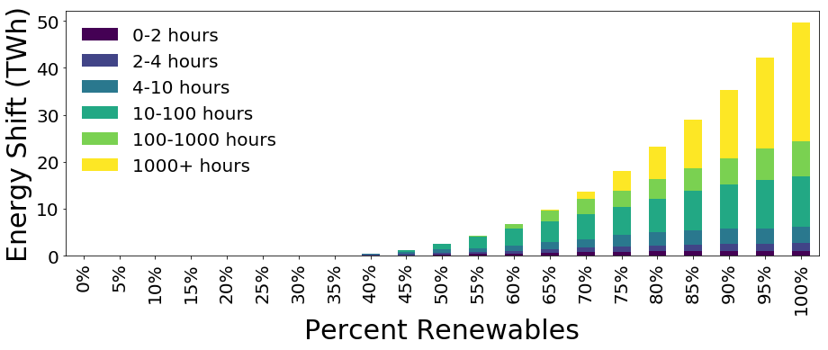

```python
df_duration.plot(kind='bar',stacked=True,figsize=(15,5),cmap = 'viridis');
plt.ylabel('Energy Shift (TWh)', fontsize=30)
plt.yticks(fontsize=20);
plt.xlabel('Percent Renewables', fontsize=30)
plt.xticks(fontsize=20);
plt.legend(fontsize=20,frameon=False);
```

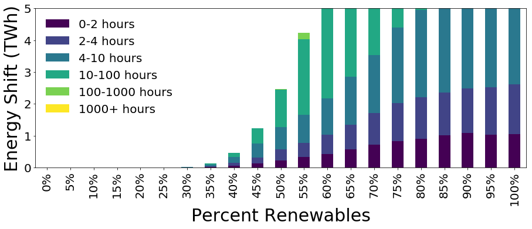

```python
df_duration.plot(kind='bar',stacked=True,figsize=(15,5),cmap='viridis');
plt.ylabel('Energy Shift (TWh)', fontsize=30)
plt.yticks(fontsize=20);
plt.xlabel('Percent Renewables', fontsize=30)
plt.xticks(fontsize=20);
plt.legend(fontsize=20,frameon=False);
plt.axis([-0.5,20.5,0,5]);
```